# Beijing PM2.5

Edward Zhang

5/25/2017

```r
library(ggplot2)
library(corrplot)
library(dplyr)
```

#### 读取文件。

```r
bjpm25 <- read.table("/Users/edwzhang/Downloads/PRSA_data_2010.1.1-2014.12.31.csv", header=TRUE, sep=",");
```

#### 生成按年，按月，按周和按日的日期。

```r
bjpm25$month[bjpm25$month<10] = paste('0',bjpm25$month[bjpm25$month<10], sep = "")
bjpm25$day[bjpm25$day<10] = paste('0',bjpm25$day[bjpm25$day<10], sep = "")
bjpm25['date'] = as.Date(do.call(paste0, bjpm25[c(2, 3, 4)]), "%Y%m%d")
bjpm25$yearDate = as.Date(cut(bjpm25$date, breaks = 'year'))
bjpm25$monthDate = as.Date(cut(bjpm25$date, breaks = 'month'))
bjpm25$weekDate = as.Date(cut(bjpm25$date, breaks = 'week', start.on.monday = TRUE))
```

#### 考虑到存在全天PM2.5数据完全缺失，用当周均值来填补NA。

```r
indx <- which(is.na(bjpm25$pm2.5), arr.ind = TRUE)
for (id in indx){
  bjpm25[id,'pm2.5'] <- mean( subset( bjpm25,weekDate==bjpm25[id,'weekDate'] )$pm2.5, na.rm=TRUE )
}
```

#### 按照PM2.5中国国家标准对数据添加分类。如果当时PM2.5计数是0，那么也划入一级。

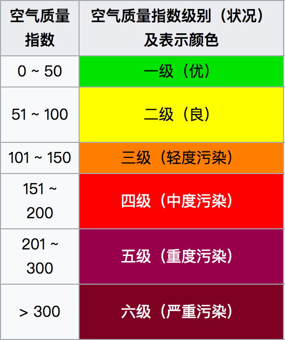

```r
bjpm25['pm25Cat'] = cut(bjpm25$pm2.5, c(0,50,100,150,200,300,1000), labels=c('I','II','III','IV','V','VI'))
bjpm25$pm25Cat[bjpm25$pm2.5==0] <- 'I'
```

#### 对累计风速按照蒲福氏风级进行划分。由于是累计值，虽然这样划分不够严谨，但至少也能反映趋势。

#### 0 - 2 km/h; 0 - 0.5 m/s -> Calm

#### 2 - 12 km/h; 0.5 - 3.3 m/s -> Light

#### 12 - 20 km/h; 3.3 - 5.5 m/s -> Gentle

#### 20 - 30 km/h; 5.5 - 8.3 m/s -> Moderate

#### 30 - 40 km/h; 8.3 - 11.1 m/s -> Fresh

#### 40 - 50 km/h; 11.1 - 13.8 m/s -> Strong

#### 50 - 88 km/h; 13.8 - 24.4 m/s -> Gale

#### 88 - 118 km/h; 24.4 - 32.7 m/s -> Storm

#### 118 and above; 32.7 m/s and above -> Hurricane

```r
bjpm25['IwsCat'] = cut(bjpm25$Iws, c(0,0.5,3.3,5.5,8.3,11.1,13.8,24.4,32.7,600),labels=c('Calm','Light','Gentle','Moderate','Fresh','Strong','Gale','Storm','Hurricane'))
```

#### 北京PM2.5按年分布图

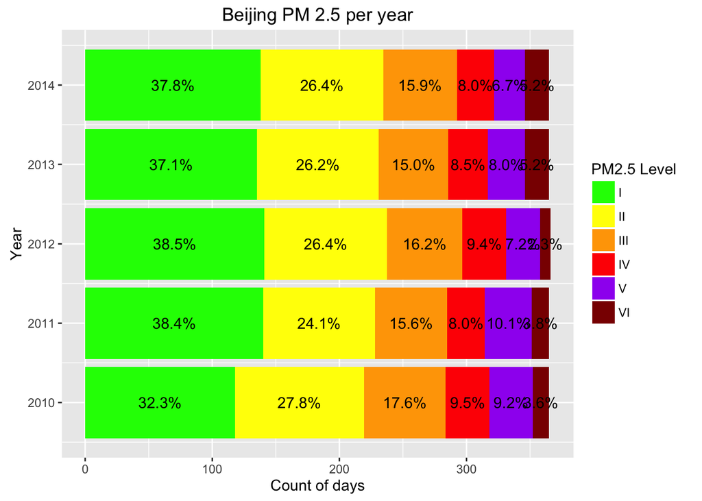

```r
ggplot(bjpm25 %>% count(yearDate, pm25Cat) %>%
       mutate(pct=n/sum(n), ypos = cumsum(n) - 0.5*n),
       aes(yearDate, n/24, fill=pm25Cat)) +
  geom_bar(stat="identity") +
  scale_x_date(date_labels = "%Y") +
  scale_fill_manual(values = c("green", "yellow", "orange","red",'purple','dark red'), guide = guide_legend(title = "PM2.5 Level")) +
  ggtitle("Beijing PM 2.5 per year") +
  coord_flip() +
  labs(y="Count of days",x="Year") +
  geom_text(aes(label=paste0(sprintf("%1.1f", pct*100),"%"), y=ypos/24))
```

##### 总体来看，2010到2012年三年中空气质量逐年好转，但是2013年又急速恶化。2014年略有提高。

#### 北京PM2.5按月分布图

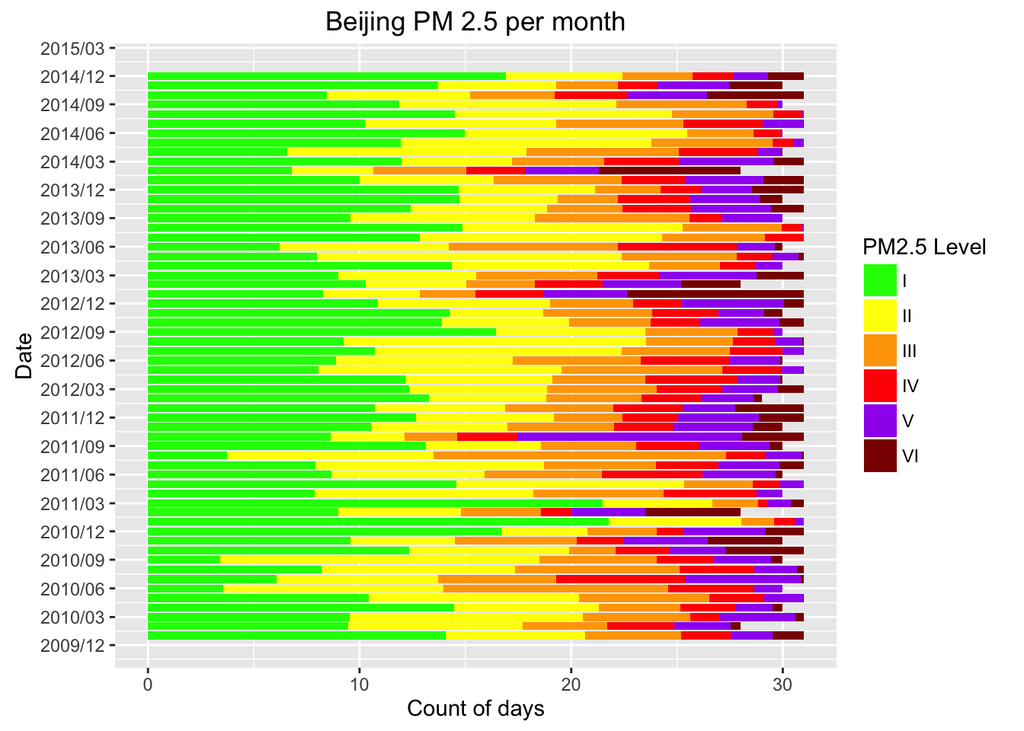

```r
ggplot(bjpm25 %>% count(monthDate, pm25Cat),
       aes(monthDate, n/24, fill=pm25Cat)) +
  geom_bar(stat="identity") +
  scale_x_date(date_labels = "%Y/%m", date_breaks = "3 months") +
  scale_fill_manual(values = c("green", "yellow", "orange","red",'purple','dark red'), guide = guide_legend(title = "PM2.5 Level")) +
  ggtitle("Beijing PM 2.5 per month") +
  coord_flip() +
  labs(y="Count of days",x="Date")
```

##### 污染爆表（6类）天多发于10，11月和1，2月。

#### 来看下污染爆表PM2.5达到令人发指的800以上分别有哪几天。

```r
bjpm25$date[bjpm25$pm2.5>800]
```

```
##  [1] "2010-02-14" "2012-01-23" "2012-01-23" "2013-01-12" "2013-01-12"
##  [6] "2013-01-12" "2013-01-12" "2013-01-12" "2013-01-12" "2013-01-12"
## [11] "2013-01-12"
```

##### 巧合的是，2010-02-14和2012-01-23分别是2010和2012农历新年的大年初一。

#### 让我们重点关注下春节前后PM2.5的变化。

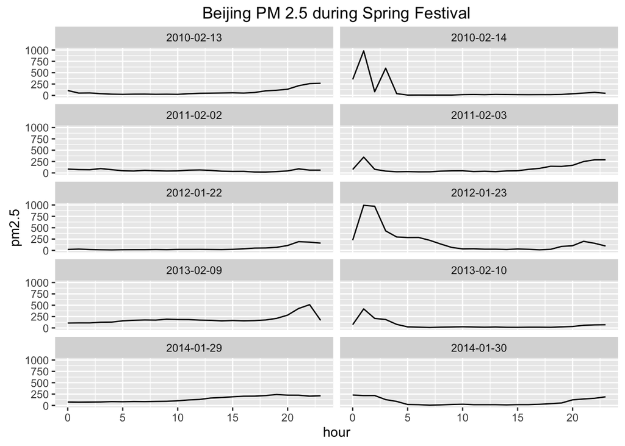

```r
bjpm25_newyear <- subset(bjpm25, date %in% as.Date(c('2010-02-13','2010-02-14','2011-02-02','2011-02-03','2012-01-22','2012-01-23','2013-02-09','2013-02-10','2014-01-29','2014-01-30')))
bjpm25_newyear$date <- factor(bjpm25_newyear$date)

ggplot(data=bjpm25_newyear, aes(x=hour, y=pm2.5)) +
  geom_line() +
  ggtitle("Beijing PM 2.5 during Spring Festival") +
  facet_wrap(~date, nrow = 5)
```

##### 有意思的是，2010到2012这3年每逢春节跨年PM2.5都明显飙升，但是2013年有明显收敛，甚至2014年还略有下降。

#### PM2.5按月直方图

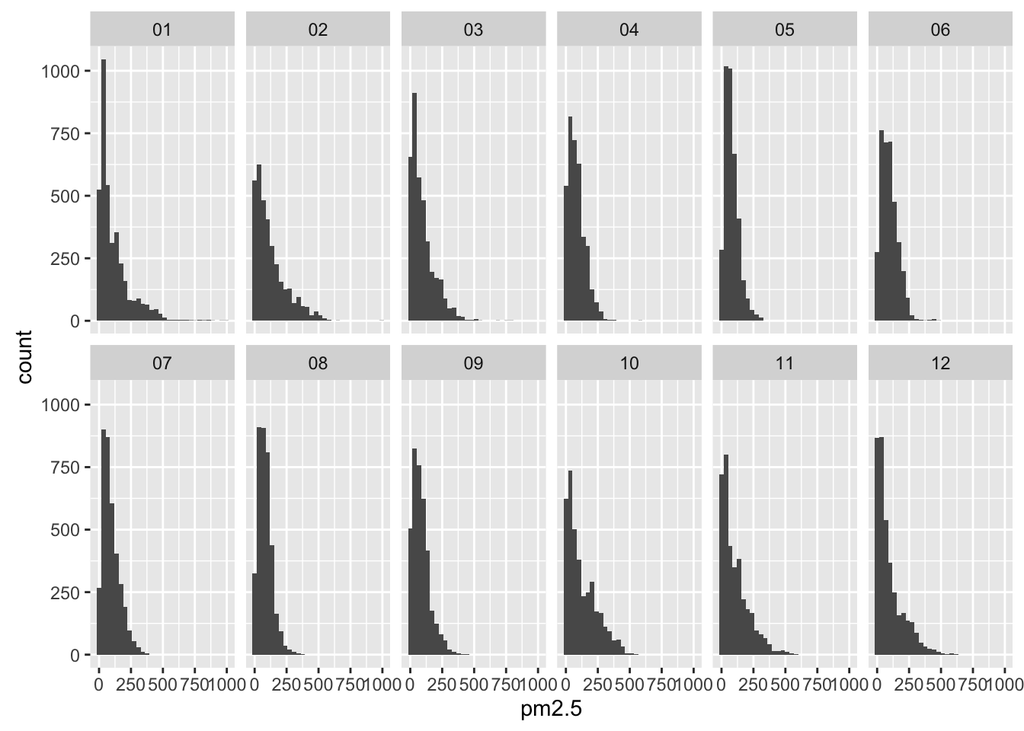

```r
ggplot(data=bjpm25, aes(x=pm2.5)) +
  geom_histogram() +
  facet_wrap(~month, nrow = 2)
```

##### 总体而言，1，2，3，10，11，12月份的空气质量相对较差。

#### PM2.5按小时直方图

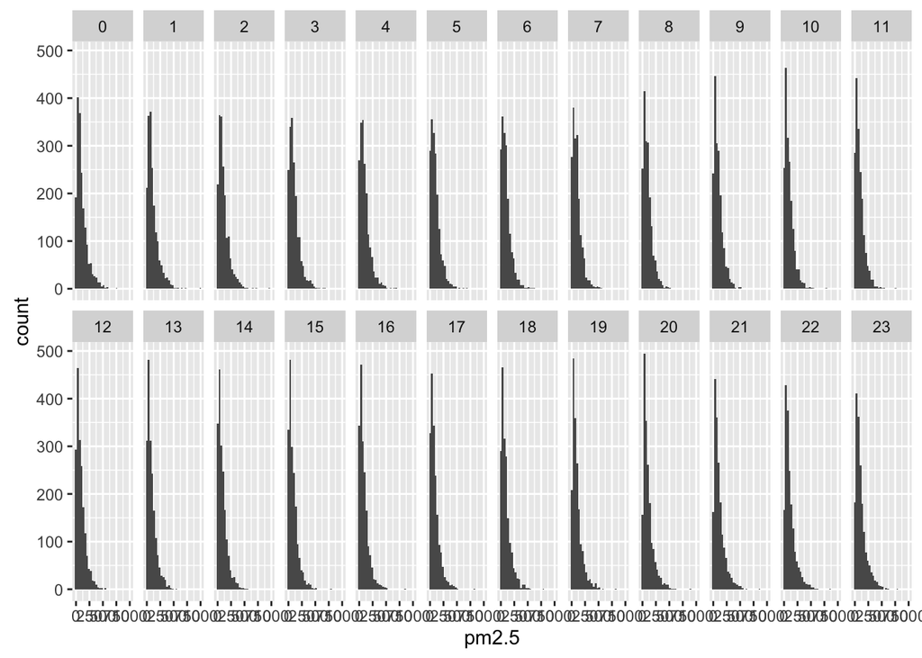

```r
ggplot(data=bjpm25, aes(x=pm2.5)) +
  geom_histogram() +
  facet_wrap(~hour, nrow = 2)
```

#### PM2.5和累计风速分类箱图

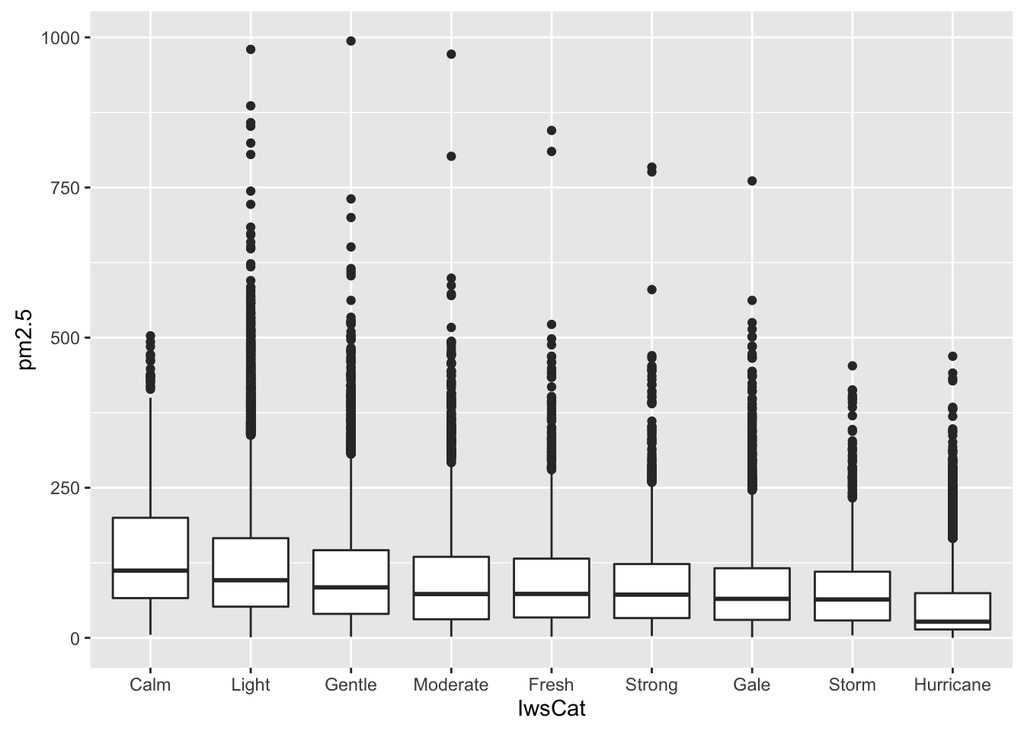

```r
ggplot(data=bjpm25, aes(x=IwsCat, y=pm2.5)) +
  geom_boxplot()
```

##### 随着风力增强，PM2.5均值值逐步下降，整体空气质量也向好。

#### PM2.5和风向箱图

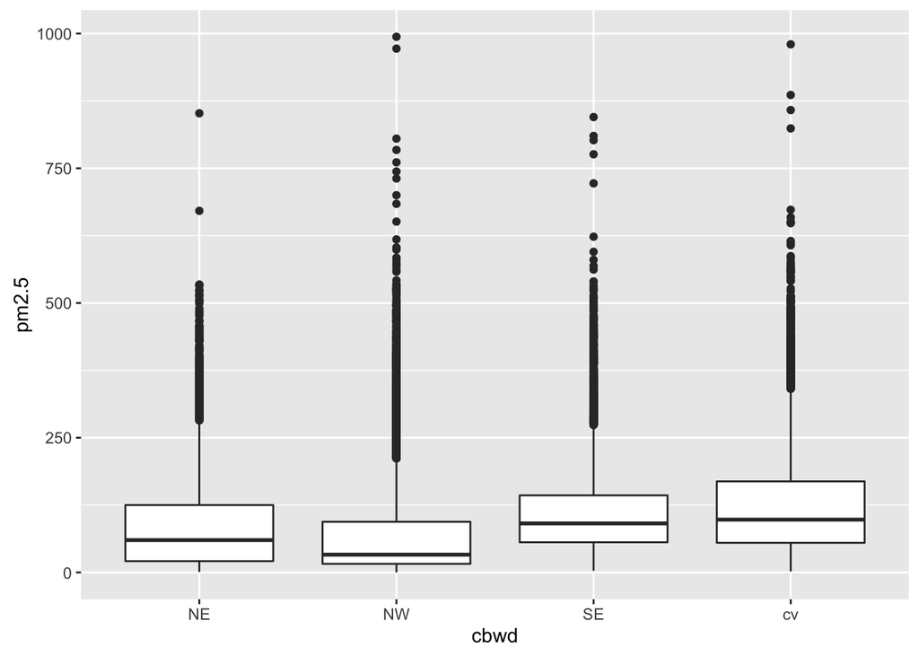

```r
ggplot(data=bjpm25, aes(x=cbwd, y=pm2.5)) +
  geom_boxplot()
```

##### 显然，刮西北风的时候空气质量较好。

#### PM2.5,累计风速分类和风向散点图

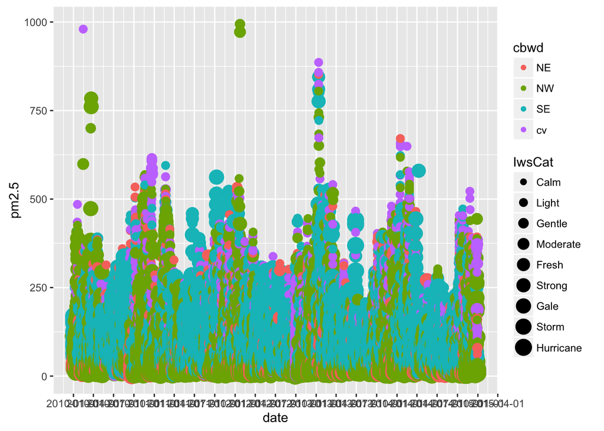

```r
ggplot(data=bjpm25, aes(x=date,y=pm2.5, size =IwsCat , color = cbwd)) +
  geom_point() +
  scale_x_date(date_breaks = "3 month")
```

##### 再次应证沉在下面的多是风力较强的西北风，同时期的空气质量相对较好。

#### 相关系数

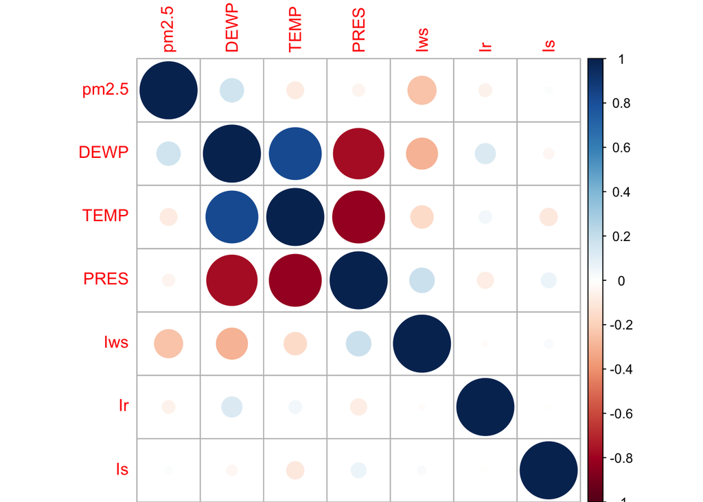

```r
corrplot(cor(bjpm25[,c('pm2.5','DEWP','TEMP','PRES','Iws','Ir','Is')]), method = "circle")
```